# Packages

```r
library(ggplot2)
library(tsibble)
library(tseries)
library(MASS)
library(forecast)
library(TSA)
library(TTR)
library(aTSA)
library(graphics)
if (!requireNamespace("readxl", quietly = TRUE)) install.packages("readxl")
library(readxl)
```

# Data Real

Data yang digunakan adalah data *Consumer Price Index for All Urban Consumers: All Items in U.S. City Average* (persentase perubahan dari tahun sebelumnya, bulanan, *seasonally adjusted*) dari FRED. Data terdiri dari 180 periode, yaitu Januari 1963 sampai Desember 1977. Seluruh data digunakan.

```r
file.excel <- "C:/Users/Fanka/Downloads/Data CPIAUCSL_PC1 (1).xlsx"


datacpi <- readxl::read_excel(file.excel, sheet = "Monthly")
head(datacpi)
```

```
## # A tibble: 6 × 2
##   observation_date    CPIAUCSL_PC1
##   <dttm>                     <dbl>
## 1 1963-01-01 00:00:00        1.33
## 2 1963-02-01 00:00:00        1.23
## 3 1963-03-01 00:00:00        1.13
## 4 1963-04-01 00:00:00        0.894
## 5 1963-05-01 00:00:00        0.893
## 6 1963-06-01 00:00:00        1.32
```

```r
str(datacpi)
```

```
## tibble [180 × 2] (S3: tbl_df/tbl/data.frame)
##  $ observation_date: POSIXct[1:180], format: "1963-01-01" "1963-02-01" ...
##  $ CPIAUCSL_PC1    : num [1:180] 1.332 1.229 1.127 0.894 0.893 ...
```

```r
datacpi <- as.data.frame(datacpi[, c("observation_date", "CPIAUCSL_PC1")])
datacpi.ts <- ts(datacpi$CPIAUCSL_PC1)
n <- length(datacpi.ts)
n
```

```
## [1] 180
```

## Eksplorasi Data

### Plot Data Penuh

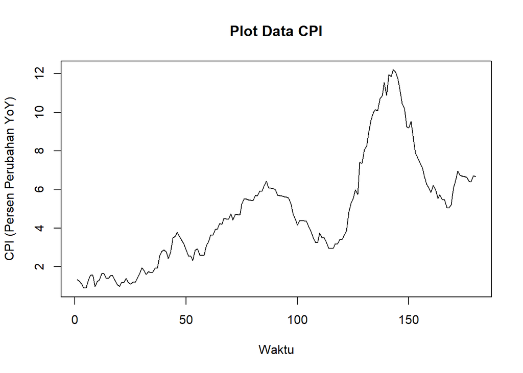

```r
plot.ts(datacpi.ts,
        lty = 1,
        xlab = "Waktu",
        ylab = "CPI (Persen Perubahan YoY)",
        main = "Plot Data CPI")
```

Berdasarkan plot data deret waktu, terlihat bahwa data memiliki pola yang naik dari waktu ke waktu dan tidak bergerak pada nilai tengah tertentu (terdapat tren, dengan lonjakan pada bagian akhir data). Pembagian data latih dan data uji ditetapkan dengan proporsi 86%:14%.

```r
n.train <- round(0.86 * n)
n.test  <- n - n.train
c(train = n.train, test = n.test)
```

```
## train  test
##   155    25
```

### Plot Data Latih

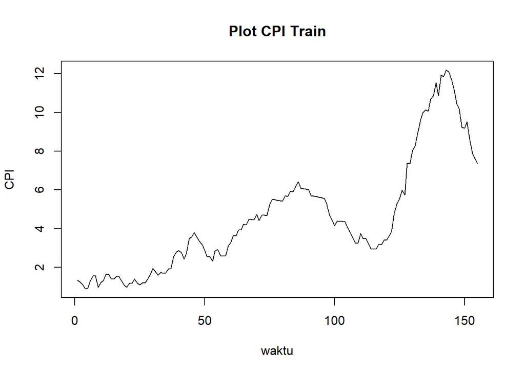

```r
cpitrain <- datacpi$CPIAUCSL_PC1[1:n.train]
train.ts <- ts(cpitrain)
plot.ts(train.ts, lty = 1, xlab = "waktu", ylab = "CPI", main = "Plot CPI Train")
```

Berdasarkan plot data deret waktu pada data latih, terlihat bahwa data cenderung memiliki tren yang naik dan cenderung tidak bergerak pada nilai tengah tertentu. Hal ini mengindikasikan bahwa data tidak stasioner dalam rataan.

### Plot Data Uji

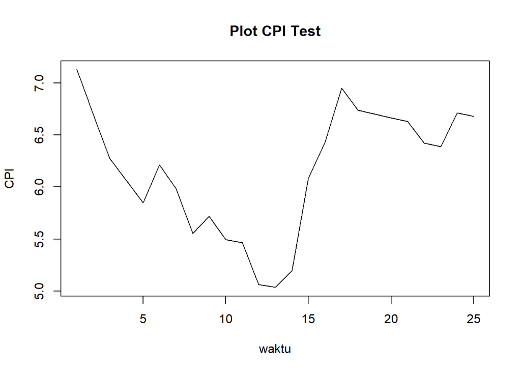

```r
cpitest <- datacpi$CPIAUCSL_PC1[(n.train + 1):n]
test.ts <- ts(cpitest)
plot.ts(test.ts, lty = 1, xlab = "waktu", ylab = "CPI", main = "Plot CPI Test")
```

## Uji Stasioneritas Data

### Plot ACF

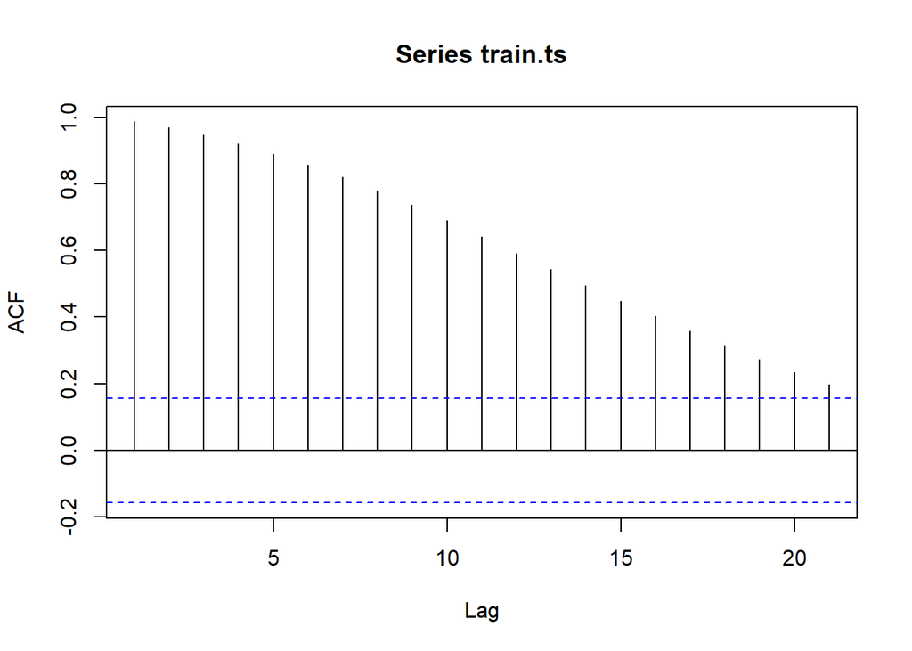

```r
acf(train.ts)
```

Berdasarkan plot ACF, terlihat bahwa plot ACF data menurun secara perlahan (*tails off slowly*). Hal ini juga menjadi indikasi bahwa data tidak stasioner dalam rataan.

### Uji ADF

```r
tseries::adf.test(train.ts)
```

```
##
##  Augmented Dickey-Fuller Test
##
## data:  train.ts
## Dickey-Fuller = -3.2589, Lag order = 5, p-value = 0.08065
## alternative hypothesis: stationary
```

$H_0$ : Data tidak stasioner dalam rataan

$H_1$ : Data stasioner dalam rataan

Berdasarkan uji ADF tersebut, jika p-value lebih besar dari taraf nyata 5% maka tak tolak $H_0$ dan menandakan bahwa data tidak stasioner dalam rataan. Hal ini sesuai dengan hasil eksplorasi menggunakan plot deret waktu dan plot ACF, sehingga ketidakstasioneran data kedepannya harus ditangani.

### Plot Box-Cox

```r
index <- seq(1:n.train)

# Box-Cox
bc <- boxcox(train.ts ~ index, lambda = seq(-2, 2, by = 0.1))
```

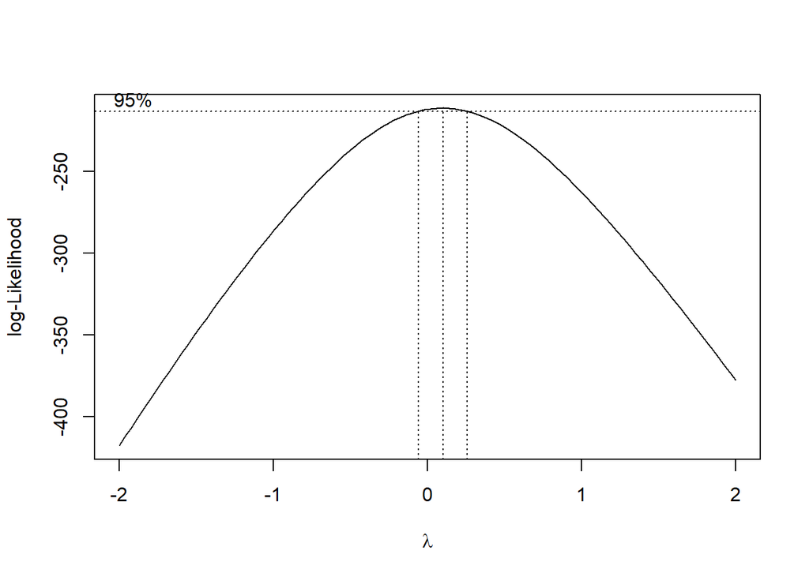

```r
# Nilai lambda optimum
lambda_opt <- bc$x[which.max(bc$y)]
lambda_opt
```

```
## [1] 0.1010101
```

```r
# Selang kepercayaan 95% untuk lambda
ci_lambda <- bc$x[bc$y > max(bc$y) - 0.5 * qchisq(0.95, df = 1)]

# Batas bawah dan batas atas
ci_lower <- min(ci_lambda)
ci_upper <- max(ci_lambda)
c(Batas_Bawah = ci_lower, Batas_Atas = ci_upper)
```

```
## Batas_Bawah  Batas_Atas
## -0.02020202  0.22222222
```

Jika selang kepercayaan 95% bagi $\lambda$ memuat nilai 1, maka data sudah stasioner dalam ragam. Jika tidak memuat 1, maka ketidakstasioneran ragam dapat ditangani dengan transformasi sesuai nilai $\lambda$ optimum. Pada praktikum ini penanganan difokuskan pada ketidakstasioneran dalam rataan melalui *differencing*.

## Penanganan Ketidakstasioneran Data

Differencing pertama dilakukan terlebih dahulu, kemudian kestasionerannya diuji.

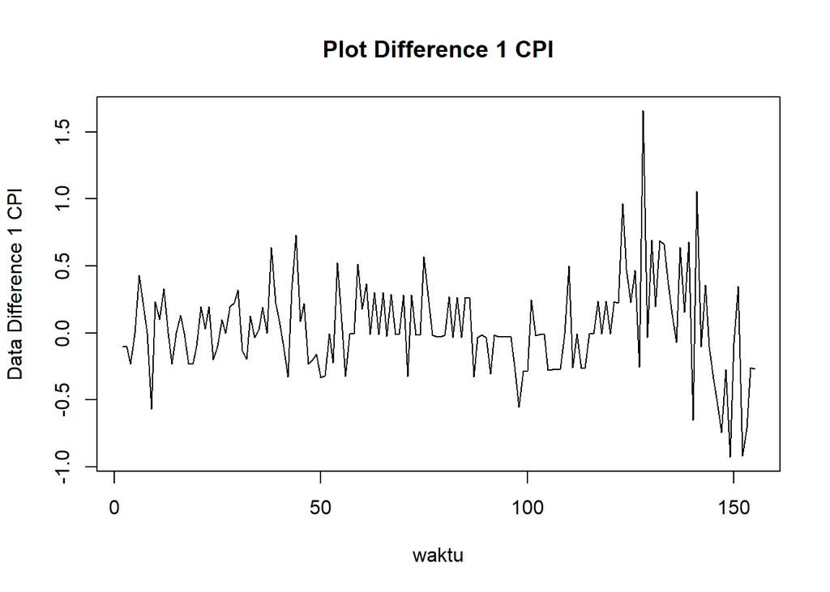

```r
# Differencing pertama
train.diff1 <- diff(train.ts, differences = 1)

plot.ts(train.diff1, lty = 1, xlab = "waktu",
        ylab = "Data Difference 1 CPI", main = "Plot Difference 1 CPI")
```

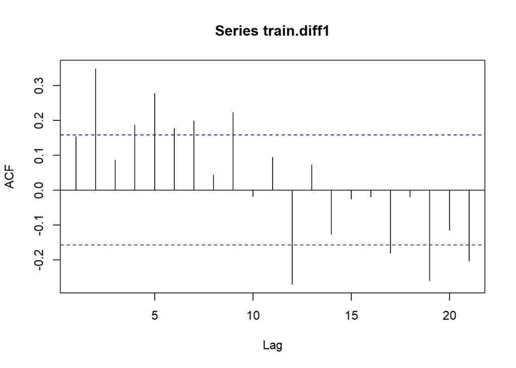

```r
acf(train.diff1)
```

```r
tseries::adf.test(train.diff1)
```

```
##
##  Augmented Dickey-Fuller Test
##
## data:  train.diff1
## Dickey-Fuller = -2.3249, Lag order = 5, p-value = 0.441
## alternative hypothesis: stationary
```

Setelah differencing pertama, plot ACF masih menunjukkan autokorelasi yang bertahan pada beberapa lag dan uji ADF belum menolak $H_0$ (p-value masih di atas 5%), sehingga data belum stasioner dalam rataan. Oleh karena itu dilakukan differencing kedua.

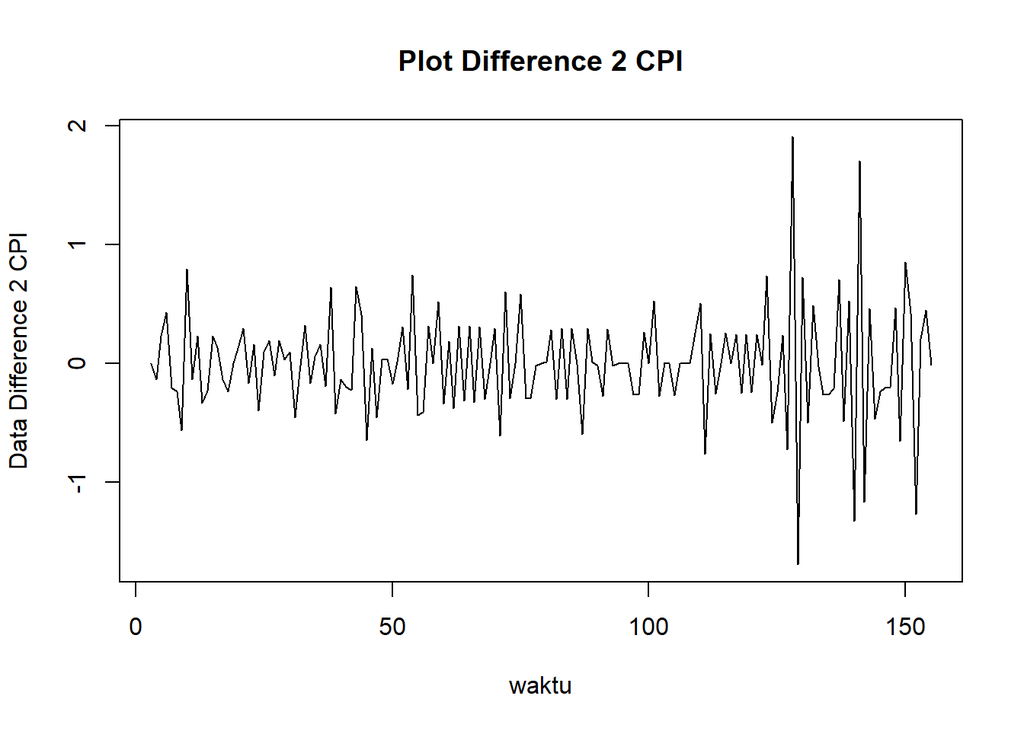

```r
# Differencing kedua
train.diff <- diff(train.ts, differences = 2)

plot.ts(train.diff, lty = 1, xlab = "waktu",
        ylab = "Data Difference 2 CPI", main = "Plot Difference 2 CPI")
```

Berdasarkan plot data deret waktu, terlihat bahwa data setelah differencing kedua bergerak di sekitar nilai tengah nol (tidak terdapat tren), sehingga data sudah stasioner dalam rataan.

### Plot ACF

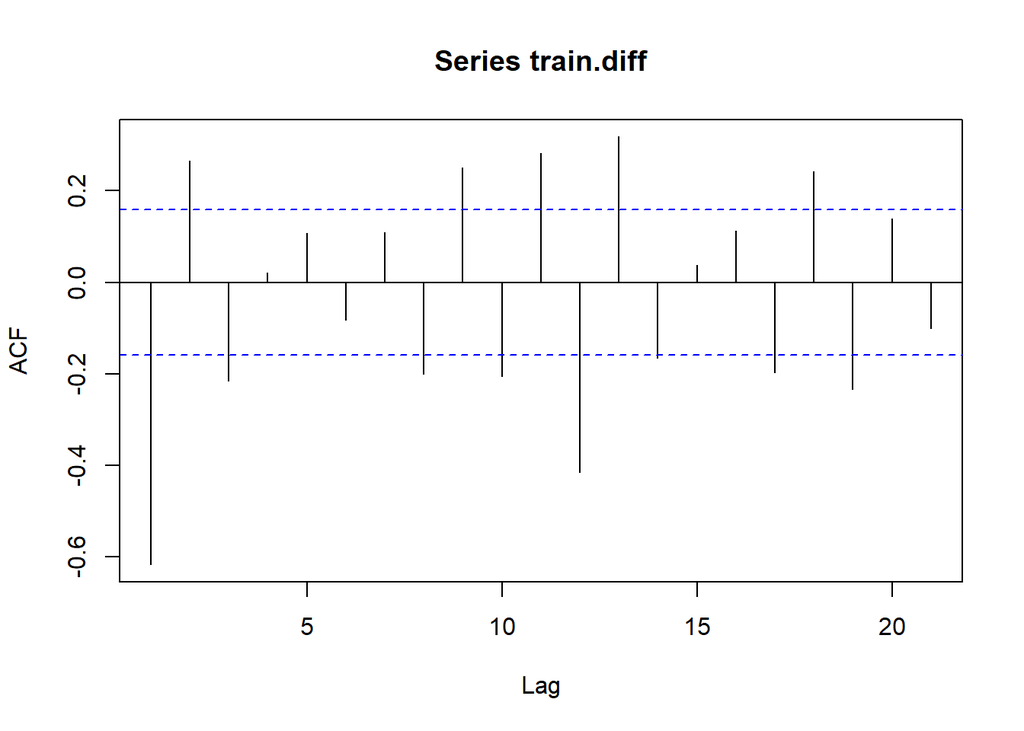

```r
acf(train.diff)
```

Berdasarkan plot tersebut, terlihat bahwa plot ACF turun cepat dan tidak lagi menunjukkan pola menurun perlahan. Hal ini menandakan data sudah stasioner dalam rataan.

### Uji ADF

```r
tseries::adf.test(train.diff)
```

```
##
##  Augmented Dickey-Fuller Test
##
## data:  train.diff
## Dickey-Fuller = -7.8821, Lag order = 5, p-value = 0.01
## alternative hypothesis: stationary
```

$H_0$ : Data tidak stasioner dalam rataan

$H_1$ : Data stasioner dalam rataan

Berdasarkan uji ADF tersebut, didapat p-value yang lebih kecil dari taraf nyata 5% sehingga tolak $H_0$ atau data stasioner dalam rataan. Hal ini sesuai dengan hasil eksplorasi menggunakan plot deret waktu dan plot ACF, sehingga ketidakstasioneran data sudah berhasil ditangani dan dapat dilanjutkan ke pemodelan dengan orde differencing $d = 2$.

```r
# Box-Cox pada data hasil differencing (data digeser agar bernilai positif)
index_diff <- seq(1:length(train.diff))

min_val <- min(train.diff)
if (min_val <= 0) {
  c_shift <- abs(min_val) + 1
  train.diff_shifted <- train.diff + c_shift
} else {
  train.diff_shifted <- train.diff
}

bc_diff <- boxcox(train.diff_shifted ~ index_diff, lambda = seq(-2, 2, by = 0.1))
```

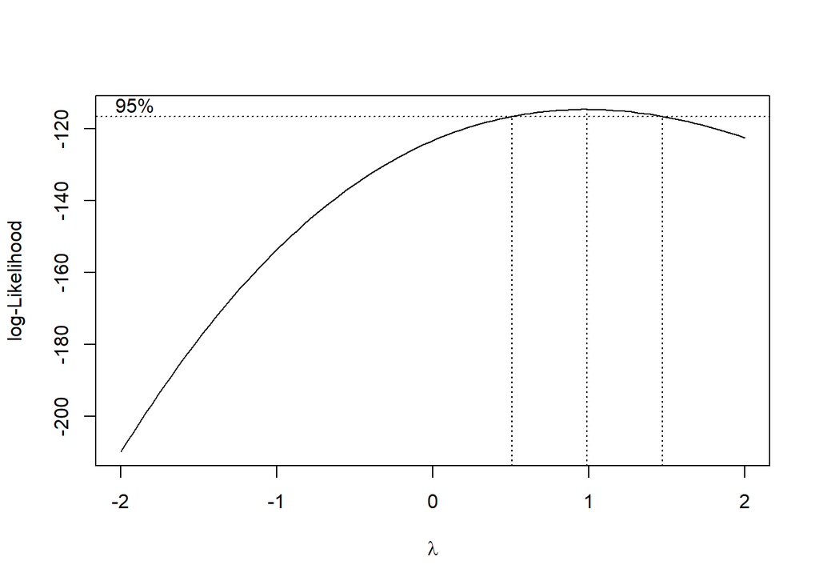

```r
lambda_opt_diff <- bc_diff$x[which.max(bc_diff$y)]
print(paste("Lambda optimum setelah diff:", lambda_opt_diff))
```

```
## [1] "Lambda optimum setelah diff: 0.98989898989899"
```

```r
ci_lambda_diff <- bc_diff$x[bc_diff$y > max(bc_diff$y) - 0.5 * qchisq(0.95, df = 1)]
c(Batas_Bawah = min(ci_lambda_diff), Batas_Atas = max(ci_lambda_diff))
```

```
## Batas_Bawah  Batas_Atas
##   0.5454545   1.4343434
```

## Identifikasi Model

### Plot ACF

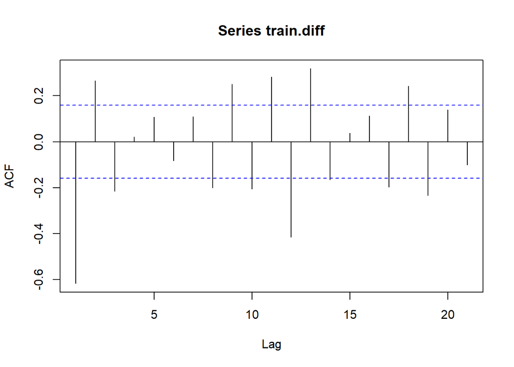

```r
acf(train.diff)
```

Berdasarkan plot tersebut, terlihat bahwa plot ACF memiliki spike signifikan pada lag awal (lag 1 negatif cukup besar) lalu mengecil, sehingga jika plot PACF dianggap *tails off*, maka model tentatifnya adalah ARIMA(0,2,1) atau ARIMA(0,2,2).

### Plot PACF

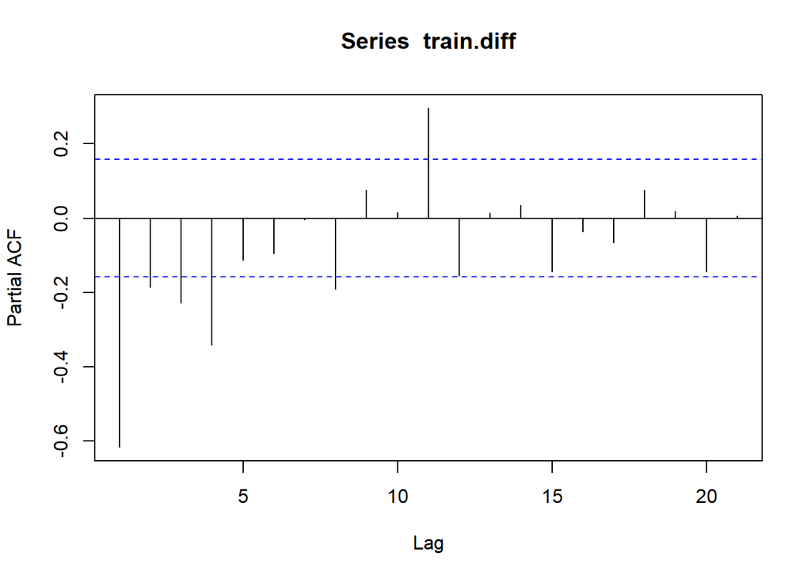

```r
pacf(train.diff)
```

Berdasarkan plot tersebut, terlihat bahwa plot PACF memiliki beberapa spike signifikan pada lag-lag awal, sehingga jika plot ACF dianggap *cuts off*, maka model tentatifnya adalah ARIMA(2,2,0).

Jika baik plot ACF maupun plot PACF keduanya dianggap *tails off*, maka model yang terbentuk adalah ARIMA(1,2,1).

### Plot EACF

```r
eacf(train.diff)
```

```
## AR/MA
##   0 1 2 3 4 5 6 7 8 9 10 11 12 13
## 0 x x x o o o o x x x x  x  x  o
## 1 x x x o x o o o o o o  x  x  x
## 2 x o x o x o o o o o o  x  o  o
## 3 x o x o o o o o o o o  x  o  o
## 4 x o o x o o o o o o o  x  o  o
## 5 x x o x o o o o o o o  x  o  o
## 6 o o o x x o o o o o o  x  o  o
## 7 o x x x x o o o o o o  x  o  o
```

## Pendugaan Parameter Model Tentatif

Karena data sudah di-*differencing* dua kali, model diduga pada data `train.diff` dengan orde $d = 0$ (tanpa konstanta karena rata-rata data hasil differencing kedua mendekati nol).

### ARIMA(0,2,1)

```r
model1.da <- Arima(train.diff, order = c(0,0,1), include.mean = FALSE, method = "ML")
summary(model1.da)
```

```
## Series: train.diff
## ARIMA(0,0,1) with zero mean
##
## Coefficients:
##           ma1
##       -0.8022
## s.e.   0.0435
##
## sigma^2 = 0.1113:  log likelihood = -49.15
## AIC=102.3   AICc=102.38   BIC=108.36
##
## Training set error measures:
##                        ME      RMSE       MAE      MPE     MAPE      MASE
## Training set -0.008818263 0.3325128 0.2461499 2528.843 6960.751 0.4317539
##                    ACF1
## Training set -0.1334471
```

```r
lmtest::coeftest(model1.da)
```

```
##
## z test of coefficients:
##
##      Estimate Std. Error z value  Pr(>|z|)
## ma1 -0.802186   0.043501 -18.441 < 2.2e-16 ***
## ---
## Signif. codes:  0 '***' 0.001 '**' 0.01 '*' 0.05 '.' 0.1 ' ' 1
```

### ARIMA(0,2,2)

```r
model2.da <- Arima(train.diff, order = c(0,0,2), include.mean = FALSE, method = "ML")
summary(model2.da)
```

```
## Series: train.diff
## ARIMA(0,0,2) with zero mean
##
## Coefficients:
##           ma1     ma2
##       -0.9100  0.1298
## s.e.   0.0785  0.0731
##
## sigma^2 = 0.1097:  log likelihood = -47.56
## AIC=101.12   AICc=101.29   BIC=110.22
##
## Training set error measures:
##                        ME      RMSE       MAE      MPE     MAPE      MASE
## Training set -0.008529804 0.3290308 0.2463292 3080.058 8106.502 0.4320685
##                     ACF1
## Training set -0.01496916
```

```r
lmtest::coeftest(model2.da)
```

```
##
## z test of coefficients:
##
##      Estimate Std. Error  z value Pr(>|z|)
## ma1 -0.910001   0.078478 -11.5956  < 2e-16 ***
## ma2  0.129823   0.073062   1.7769  0.07558 .
## ---
## Signif. codes:  0 '***' 0.001 '**' 0.01 '*' 0.05 '.' 0.1 ' ' 1
```

### ARIMA(1,2,1)

```r
model3.da <- Arima(train.diff, order = c(1,0,1), include.mean = FALSE, method = "ML")
summary(model3.da)
```

```
## Series: train.diff
## ARIMA(1,0,1) with zero mean
##
## Coefficients:
##           ar1      ma1
##       -0.1928  -0.7354
## s.e.   0.0952   0.0636
##
## sigma^2 = 0.1092:  log likelihood = -47.19
## AIC=100.39   AICc=100.55   BIC=109.48
##
## Training set error measures:
##                        ME      RMSE       MAE      MPE     MAPE      MASE
## Training set -0.008377749 0.3282377 0.2456493 3326.141 8584.578 0.4308759
##                    ACF1
## Training set 0.01119142
```

```r
lmtest::coeftest(model3.da)
```

```
##
## z test of coefficients:
##
##      Estimate Std. Error  z value Pr(>|z|)
## ar1 -0.192835   0.095215  -2.0253  0.04284 *
## ma1 -0.735377   0.063637 -11.5558  < 2e-16 ***
## ---
## Signif. codes:  0 '***' 0.001 '**' 0.01 '*' 0.05 '.' 0.1 ' ' 1
```

### ARIMA(2,2,0)

```r
model4.da <- Arima(train.diff, order = c(2,0,0), include.mean = FALSE, method = "ML")
summary(model4.da)
```

```
## Series: train.diff
## ARIMA(2,0,0) with zero mean
##
## Coefficients:
##           ar1      ar2
##       -0.7276  -0.1852
## s.e.   0.0793   0.0793
##
## sigma^2 = 0.1244:  log likelihood = -56.94
## AIC=119.88   AICc=120.04   BIC=128.97
##
## Training set error measures:
##                        ME      RMSE      MAE      MPE     MAPE      MASE
## Training set -0.002546329 0.3504473 0.263511 5356.081 11264.81 0.4622059
##                     ACF1
## Training set -0.04748192
```

```r
lmtest::coeftest(model4.da)
```

```
##
## z test of coefficients:
##
##      Estimate Std. Error z value Pr(>|z|)
## ar1 -0.727572   0.079306 -9.1743  < 2e-16 ***
## ar2 -0.185187   0.079331 -2.3343  0.01958 *
## ---
## Signif. codes:  0 '***' 0.001 '**' 0.01 '*' 0.05 '.' 0.1 ' ' 1
```

### ARIMA(1,2,2)

```r
model5.da <- Arima(train.diff, order = c(1,0,2), include.mean = FALSE, method = "ML")
summary(model5.da)
```

```
## Series: train.diff
## ARIMA(1,0,2) with zero mean
##
## Coefficients:
##           ar1      ma1      ma2
##       -0.6207  -0.3048  -0.3402
## s.e.   0.1741   0.1894   0.1560
##
## sigma^2 = 0.1083:  log likelihood = -46.08
## AIC=100.15   AICc=100.42   BIC=112.27
##
## Training set error measures:
##                        ME      RMSE       MAE      MPE     MAPE      MASE
## Training set -0.008342554 0.3258426 0.2428495 3093.648 9260.118 0.4259649
##                    ACF1
## Training set 0.01709205
```

```r
lmtest::coeftest(model5.da)
```

```
##
## z test of coefficients:
##
##     Estimate Std. Error z value  Pr(>|z|)
## ar1 -0.62073    0.17411 -3.5651 0.0003638 ***
## ma1 -0.30481    0.18944 -1.6090 0.1076070
## ma2 -0.34015    0.15604 -2.1800 0.0292602 *
## ---
## Signif. codes:  0 '***' 0.001 '**' 0.01 '*' 0.05 '.' 0.1 ' ' 1
```

### ARIMA(2,2,1)

```r
model6.da <- Arima(train.diff, order = c(2,0,1), include.mean = FALSE, method = "ML")
summary(model6.da)
```

```
## Series: train.diff
## ARIMA(2,0,1) with zero mean
##
## Coefficients:
##           ar1     ar2      ma1
##       -0.1182  0.1336  -0.7932
## s.e.   0.1113  0.1029   0.0719
##
## sigma^2 = 0.1086:  log likelihood = -46.31
## AIC=100.61   AICc=100.88   BIC=112.74
##
## Training set error measures:
##                        ME      RMSE       MAE      MPE     MAPE      MASE
## Training set -0.008193488 0.3263572 0.2431312 3682.212 9483.047 0.4264592
##                    ACF1
## Training set 0.01212412
```

```r
lmtest::coeftest(model6.da)
```

```
##
## z test of coefficients:
##
##      Estimate Std. Error  z value Pr(>|z|)
## ar1 -0.118228   0.111303  -1.0622   0.2881
## ar2  0.133607   0.102912   1.2983   0.1942
## ma1 -0.793208   0.071942 -11.0257   <2e-16 ***
## ---
## Signif. codes:  0 '***' 0.001 '**' 0.01 '*' 0.05 '.' 0.1 ' ' 1
```

## Ringkasan AIC

```r
model_tentatif <- data.frame(
  Model = c("ARIMA(0,2,1)", "ARIMA(0,2,2)", "ARIMA(1,2,1)",
            "ARIMA(2,2,0)", "ARIMA(1,2,2)", "ARIMA(2,2,1)"),
  AIC   = c(AIC(model1.da), AIC(model2.da), AIC(model3.da),
            AIC(model4.da), AIC(model5.da), AIC(model6.da)),
  BIC   = c(BIC(model1.da), BIC(model2.da), BIC(model3.da),
            BIC(model4.da), BIC(model5.da), BIC(model6.da))
)
model_tentatif[order(model_tentatif$AIC), ]
```

```
##          Model      AIC      BIC
## 5 ARIMA(1,2,2) 100.1505 112.2722
## 3 ARIMA(1,2,1) 100.3873 109.4786
## 6 ARIMA(2,2,1) 100.6140 112.7357
## 2 ARIMA(0,2,2) 101.1246 110.2159
## 1 ARIMA(0,2,1) 102.2971 108.3580
## 4 ARIMA(2,2,0) 119.8832 128.9745
```

## Analisis Sisaan

Model terbaik hasil identifikasi kemudian dicek asumsi sisaannya. Sisaan model ARIMA harus memenuhi asumsi normalitas, kebebasan sisaan, kehomogenan ragam, dan nilai tengah nol. Diagnostik model dilakukan secara eksplorasi dan uji formal.

### Eksplorasi Sisaan

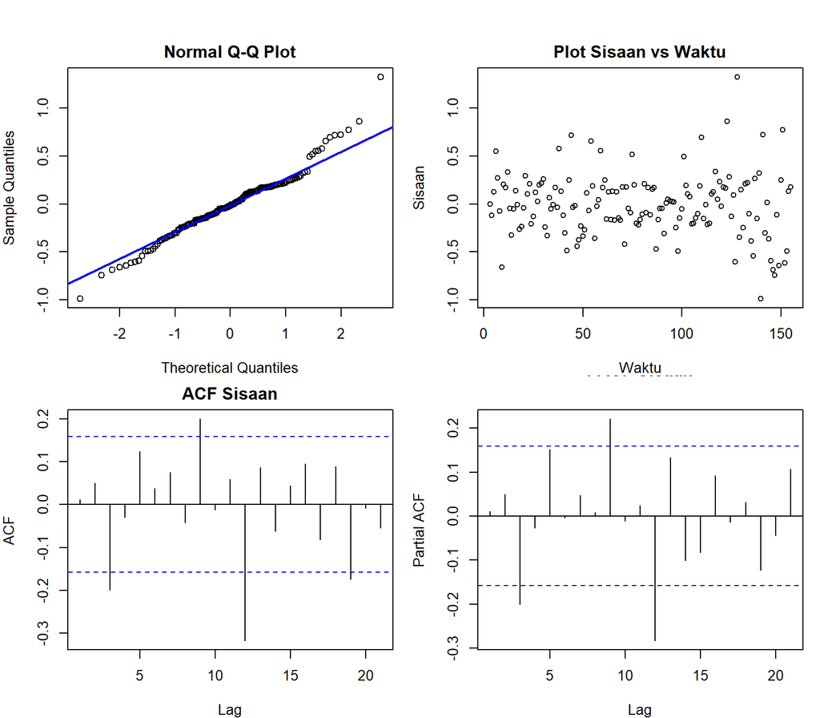

```r
sisaan.da <- model3.da$residuals

par(mfrow = c(2,2),
    mar = c(4,4,2,1),
    oma = c(0,0,2,0))

# Q-Q Plot
qqnorm(sisaan.da, main = "Normal Q-Q Plot")
qqline(sisaan.da, col = "blue", lwd = 2)

# Plot Sisaan vs Waktu
plot(sisaan.da, type = "p",
     main = "Plot Sisaan vs Waktu",
     xlab = "Waktu", ylab = "Sisaan")

# ACF
acf(sisaan.da, main = "ACF Sisaan")

# PACF
pacf(sisaan.da, main = "PACF Sisaan")
```

```r
par(mfrow = c(1,1))
```

### Uji Formal

**1) Sisaan menyebar normal**

```r
ks.test(sisaan.da, "pnorm", mean = mean(sisaan.da), sd = sd(sisaan.da))
```

```
##
##  Asymptotic one-sample Kolmogorov-Smirnov test
##
## data:  sisaan.da
## D = 0.087208, p-value = 0.195
## alternative hypothesis: two-sided
```

$H_0$ : Sisaan menyebar normal

$H_1$ : Sisaan tidak menyebar normal

Apabila p-value kurang dari taraf nyata 5% maka tolak $H_0$ dan sisaan tidak menyebar normal. Hasil ini dapat dibandingkan dengan eksplorasi menggunakan plot kuantil-kuantil normal.

**2) Sisaan saling bebas / tidak ada autokorelasi**

```r
Box.test(sisaan.da, type = "Ljung")
```

```
##
##  Box-Ljung test
##
## data:  sisaan.da
## X-squared = 0.019541, df = 1, p-value = 0.8888
```

$H_0$ : Sisaan saling bebas

$H_1$ : Sisaan tidak saling bebas

**3) Sisaan homogen**

```r
Box.test((sisaan.da)^2, type = "Ljung")
```

```
##
##  Box-Ljung test
##
## data:  (sisaan.da)^2
## X-squared = 4.543, df = 1, p-value = 0.03305
```

$H_0$ : Ragam sisaan homogen

$H_1$ : Ragam sisaan tidak homogen

Apabila p-value kurang dari taraf nyata 5% maka tolak $H_0$ dan ragam sisaan tidak homogen (terdapat indikasi heteroskedastisitas).

**4) Nilai tengah sisaan sama dengan nol**

```r
t.test(sisaan.da, mu = 0, conf.level = 0.95)
```

```
##
##  One Sample t-test
##
## data:  sisaan.da
## t = -0.31478, df = 152, p-value = 0.7534
## alternative hypothesis: true mean is not equal to 0
## 95 percent confidence interval:
##  -0.06096069  0.04420519
## sample estimates:
##    mean of x
## -0.008377749
```

$H_0$ : nilai tengah sisaan sama dengan 0

$H_1$ : nilai tengah sisaan tidak sama dengan 0

Apabila p-value lebih besar dari taraf nyata 5% maka gagal tolak $H_0$ dan nilai tengah sisaan sama dengan nol.

## Overfitting

```r
# ARIMA(2,2,1)
summary(model6.da)
```

```
## Series: train.diff
## ARIMA(2,0,1) with zero mean
##
## Coefficients:
##           ar1     ar2      ma1
##       -0.1182  0.1336  -0.7932
## s.e.   0.1113  0.1029   0.0719
##
## sigma^2 = 0.1086:  log likelihood = -46.31
## AIC=100.61   AICc=100.88   BIC=112.74
##
## Training set error measures:
##                        ME      RMSE       MAE      MPE     MAPE      MASE
## Training set -0.008193488 0.3263572 0.2431312 3682.212 9483.047 0.4264592
##                    ACF1
## Training set 0.01212412
```

```r
lmtest::coeftest(model6.da)
```

```
##
## z test of coefficients:
##
##      Estimate Std. Error  z value Pr(>|z|)
## ar1 -0.118228   0.111303  -1.0622   0.2881
## ar2  0.133607   0.102912   1.2983   0.1942
## ma1 -0.793208   0.071942 -11.0257   <2e-16 ***
## ---
## Signif. codes:  0 '***' 0.001 '**' 0.01 '*' 0.05 '.' 0.1 ' ' 1
```

```r
# ARIMA(1,2,2)
summary(model5.da)
```

```
## Series: train.diff
## ARIMA(1,0,2) with zero mean
##
## Coefficients:
##           ar1      ma1      ma2
##       -0.6207  -0.3048  -0.3402
## s.e.   0.1741   0.1894   0.1560
##
## sigma^2 = 0.1083:  log likelihood = -46.08
## AIC=100.15   AICc=100.42   BIC=112.27
##
## Training set error measures:
##                        ME      RMSE       MAE      MPE     MAPE      MASE
## Training set -0.008342554 0.3258426 0.2428495 3093.648 9260.118 0.4259649
##                    ACF1
## Training set 0.01709205
```

```r
lmtest::coeftest(model5.da)
```

```
##
## z test of coefficients:
##
##     Estimate Std. Error z value  Pr(>|z|)
## ar1 -0.62073    0.17411 -3.5651 0.0003638 ***
## ma1 -0.30481    0.18944 -1.6090 0.1076070
## ma2 -0.34015    0.15604 -2.1800 0.0292602 *
## ---
## Signif. codes:  0 '***' 0.001 '**' 0.01 '*' 0.05 '.' 0.1 ' ' 1
```

```r
model.terbaik <- Arima(train.diff, order = c(1,0,1), include.mean = FALSE, method = "ML")
summary(model.terbaik)
```

```
## Series: train.diff
## ARIMA(1,0,1) with zero mean
##
## Coefficients:
##           ar1      ma1
##       -0.1928  -0.7354
## s.e.   0.0952   0.0636
##
## sigma^2 = 0.1092:  log likelihood = -47.19
## AIC=100.39   AICc=100.55   BIC=109.48
##
## Training set error measures:
##                        ME      RMSE       MAE      MPE     MAPE      MASE
## Training set -0.008377749 0.3282377 0.2456493 3326.141 8584.578 0.4308759
##                    ACF1
## Training set 0.01119142
```

```r
lmtest::coeftest(model.terbaik)
```

```
##
## z test of coefficients:
##
##      Estimate Std. Error  z value Pr(>|z|)
## ar1 -0.192835   0.095215  -2.0253  0.04284 *
## ma1 -0.735377   0.063637 -11.5558  < 2e-16 ***
## ---
## Signif. codes:  0 '***' 0.001 '**' 0.01 '*' 0.05 '.' 0.1 ' ' 1
```

## Peramalan

Peramalan dilakukan menggunakan fungsi `forecast()`. Peramalan berikut dilakukan sebanyak panjang data uji (25 periode ke depan).

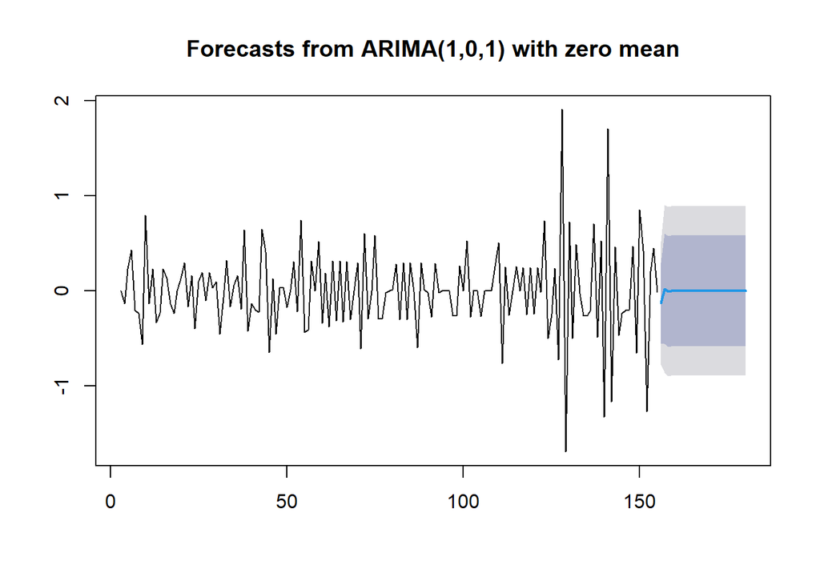

```r
# --- FORECAST pada data hasil differencing ---
ramalan.da <- forecast::forecast(model.terbaik, h = length(test.ts))
data.ramalan.da <- ramalan.da$mean
plot(ramalan.da)
```

```r
# --- Inverse differencing (d = 2) ---
# xi = dua nilai terakhir data latih
pt_akhir_train <- tail(train.ts, 2)
forecast.inv   <- diffinv(data.ramalan.da, differences = 2, xi = pt_akhir_train)

# buang dua nilai awal (nilai xi), sisanya adalah ramalan pada skala asli
hasil <- as.numeric(forecast.inv[-(1:2)])

# Bandingkan aktual vs forecast
perbandingan.da <- cbind(
  Aktual   = as.numeric(test.ts),
  Forecast = hasil
)
print(head(perbandingan.da, 10))
```

```
##        Aktual Forecast
##  [1,] 7.12909 6.984274
##  [2,] 6.69216 6.614195
##  [3,] 6.27376 6.239432
##  [4,] 6.06061 5.865573
##  [5,] 5.84906 5.491539
##  [6,] 6.21469 5.117539
##  [7,] 5.98131 4.743532
##  [8,] 5.55556 4.369527
##  [9,] 5.71956 3.995522
## [10,] 5.49451 3.621516
```

```r
# Hitung akurasi
akurasi_test <- accuracy(hasil, as.numeric(test.ts))
akurasi_test
```

```
##                ME     RMSE      MAE      MPE     MAPE
## Test set 3.666069 4.679905 3.666069 57.93664 57.93664
```

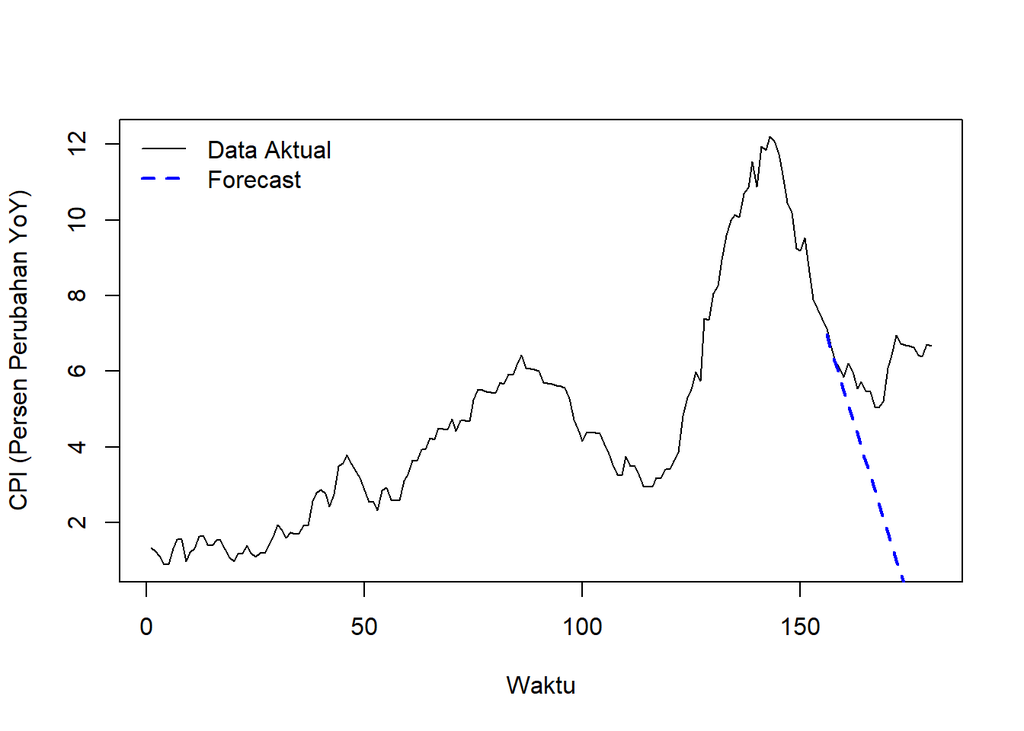

```r
# Plot data aktual vs forecast
ts.plot(datacpi.ts, col = "black", lty = 1,
        xlab = "Waktu", ylab = "CPI (Persen Perubahan YoY)")

# Garis forecast
lines((n.train + 1):(n.train + length(hasil)), hasil,
      col = "blue", lty = 2, lwd = 2)

legend("topleft",
       legend = c("Data Aktual", "Forecast"),
       col = c("black", "blue"),
       lty = c(1, 2), lwd = c(1, 2), bty = "n")
```